# Text_Mining_in_R

Shelmith Macharia

7th November, 2020

In this training, we will explore text mining using tidy data principles. We will cover the following:

- Reading text data
- Tidying text data
- Visualization
- Term frequency inverse document frequency (tf-idf)
- Sentiment analysis

```r
#Clear memory
rm(list = ls())
```

```r
#install.packages(c("tidyverse","tidytext"),dependencies = T)
require(tidytext)
library(tidyverse)
library(readtext)
library(wordcloud)
library(gridExtra)
library(pdftools)
library(tibble)
```

### 2. **Data**

We will use the Presidential speeches on COVID 19 since March 2020.

### 3. **Read the data**

There are various ways of reading text data.

- Copy and paste text data into R
- Read a from a text file, word file or pdf file

```r
#Copy and paste data into R

Data <- c("Fellow Kenyans,

Today the 16th of April, 2020 marks one month and three days since the first confirmed case of the Coronavirus Disease was recorded in our country.

As a Government, and on the advice by our medical and public health experts, we moved quickly to implement a comprehensive plan designed to limit individual exposure to the virus and its spread within our communities.

We recognised the profound need for prompt action, observing the exponential nature of the pandemic's transmission that had been recorded in other countries across the world.

The measures we have taken are firm and indeed have been impactful. The nighttime curfew, and the barring of travel in and out of the areas that have the most infections, are indeed limiting the ability of the disease to be transmitted at a great scale. The same is the case for the social distancing, the guidelines that have been set out that include amongst other things the closure of learning and entertainment institutions, as well as the barring of air travel into our country.

")


#Read a text file
Data_text <- read.delim("Speeches/March.txt", sep = "\t")

Data_text2 <- read.table("Speeches/March.txt", sep = "\t")

#Read a pdf document
Data_pdf <- pdf_text("Speeches/May1.pdf")
```

### **Reading data using the readtext package**

- Read text data using the readtext function from the readtext package.
- The package is used for importing and handling plain and formatted text files.
- The function is able to read different file types e.g. txt, csv, json, xml, pdf, doc and docx among others.
- Handles multiple files and file types.

```r
## read one file
Text1 <- readtext("Speeches/June.docx")
Text1
```

```
## readtext object consisting of 1 document and 0 docvars.
## # Description: df[,2] [1 x 2]
##   doc_id    text
##   <chr>     <chr>
## 1 June.docx "\"Fellow Ken\"..."
```

```r
## read multiple txt files
Text2 <- readtext("Speeches/*.docx")
Text2
```

```
## readtext object consisting of 1 document and 0 docvars.
## # Description: df[,2] [1 x 2]
##   doc_id    text
##   <chr>     <chr>
## 1 June.docx "\"Fellow Ken\"..."
```

```r
## read all files
Speeches <- readtext("Speeches/")
Speeches
```

```
## readtext object consisting of 10 documents and 0 docvars.
## # Description: df[,2] [10 x 2]
##   doc_id     text
##   <chr>      <chr>
## 1 April1.txt "\"Fellow Ken\"..."
## 2 April2.txt "\"Today is t\"..."
## 3 July1.txt  "\"Fellow Ken\"..."
## 4 July2.txt  "\"My Fellow \"..."
## 5 June.docx  "\"Fellow Ken\"..."
## 6 June.txt   "\"Fellow Ken\"..."
## # ... with 4 more rows
```

### **Tidying the data**

- Once we have loaded the data, the next step is to tidy the data.
- Tidy text data has one observation per row.
- We use unnest_tokens() to convert the data into a tidy format. Unnest_tokens() also removes punctuation, converts all words to lower case and retains other columns.
- We will also remove stopwords. Stop words are words that are very common in text data but are not informative e.g. of, this, and, because e.t.c.
- We will also remove numbers and funny symbols from the data.
- tidytext functions work well with data frames.

```r
#### Data frame
Data4 <- tibble(line =1,text = Data)
#### Unnest tokens and remove stopwords
Data5 <- Data4 %>%
  unnest_tokens(word, text) %>%
  count(word,sort = T)

tidytext::stop_words
```

```
## # A tibble: 1,149 x 2
##    word        lexicon
##    <chr>       <chr>
##  1 a           SMART
##  2 a's         SMART
##  3 able        SMART
##  4 about       SMART
##  5 above       SMART
##  6 according   SMART
##  7 accordingly SMART
##  8 across      SMART
##  9 actually    SMART
## 10 after       SMART
## # ... with 1,139 more rows
```

```r
##anti_join functions looks for words in our dataset that are in the stop_words dictionary and removes them from our dataset.
Data6 <- Data5 %>% anti_join(stop_words)
```

### **Removing numbers and symbols**

- We can use the gsub function: gsub(pattern, replacement, x).
- sub function is similar to gsub function. The only difference between the two is, sub replaces only the first match.

```r
x <- "2020 has been a 2020 hard year"
Numbers <- sub("2020","",x); Numbers
```

```
## [1] " has been a 2020 hard year"
```

```r
Numbers1 <- gsub("2020", "",x); Numbers1
```

```
## [1] " has been a  hard year"
```

- Other string manipulation functions are; grep , grepl, substr, stringr functions, regexpr.
- grep and grepl are used for pattern checking and string replacement.
- grepl returns TRUE when a pattern is found in the corresponding character string. -grep returns a vector of indices of the character strings that contains the pattern.
- We will use grep function to remove numbers from our dataset.

```r
Names <- c("Faith, Shelmith"); Names
```

```
## [1] "Faith, Shelmith"
```

```r
grep("Fa",Names)
```

```
## [1] 1
```

```r
grepl("Fa", Names)
```

```
## [1] TRUE
```

```r
#### Multiple datasets
Speeches_tidy <- Speeches %>% tibble() %>%
  unnest_tokens(word, text) %>%
  anti_join(stop_words) %>%
  group_by(doc_id) %>%
  count(word,sort = T) %>%
  ungroup()
Speeches_tidy1 <- Speeches_tidy[-grep("[0-9]+", Speeches_tidy$word),]
Speeches_tidy2 <- Speeches_tidy1[-grep("kenya", Speeches_tidy1$word),]


April <- Speeches_tidy2 %>% filter(doc_id == "April1.txt")
April
```

```
## # A tibble: 637 x 3
##    doc_id     word           n
##    <chr>      <chr>      <int>
##  1 April1.txt fellow        12
##  2 April1.txt medical       10
##  3 April1.txt pandemic      10
##  4 April1.txt people        10
##  5 April1.txt efforts        8
##  6 April1.txt health         8
##  7 April1.txt measures       8
##  8 April1.txt countries      7
##  9 April1.txt covid          7
## 10 April1.txt government     7
## # ... with 627 more rows
```

```r
June <- Speeches_tidy2 %>% filter(doc_id == "June.txt")
June
```

```
## # A tibble: 398 x 3
##    doc_id   word           n
##    <chr>    <chr>      <int>
##  1 June.txt health        15
##  2 June.txt days          14
##  3 June.txt economy       14
##  4 June.txt infections    14
##  5 June.txt pandemic      11
##  6 June.txt ministry      10
##  7 June.txt disease        9
##  8 June.txt june           9
##  9 June.txt protocols      9
## 10 June.txt time           9
## # ... with 388 more rows
```

### **Visualization**

- Now the data is ready for visualization.

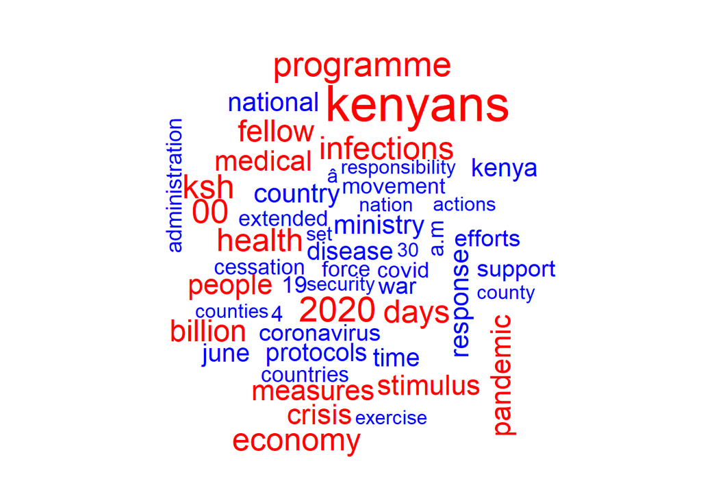

```r
## word cloud
Speeches_tidy %>%
  with(wordcloud(unique(word), n, max.words = 50, color = c( "blue", "red"),scale = c(3,0.3) ))
```

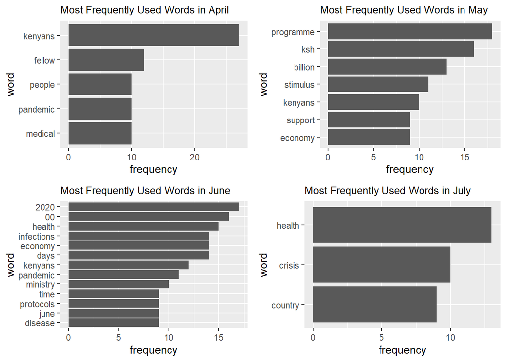

```r
### Bar chart


Speech_bar <- Speeches %>% tibble()%>%
  unnest_tokens(word, text) %>%
  anti_join(stop_words) %>%
  count(doc_id,word, sort = TRUE) %>%
  filter( n>8) %>%
  ungroup()
May <- Speech_bar %>% filter(doc_id == "May1.pdf") %>%
  mutate(word = reorder(word, n)) %>%
  ggplot(aes(word, n)) +
    geom_col() +
    xlab("word") +
    ylab("frequency") +
    ggtitle("Most Frequently Used Words in May") + theme(plot.title = element_text(size=10))+
    coord_flip()

April <- Speech_bar %>% filter(doc_id == "April1.txt") %>%
  mutate(word = reorder(word, n)) %>%
  ggplot(aes(word, n)) +
    geom_col() +
    xlab("word") +
    ylab("frequency") +
    ggtitle("Most Frequently Used Words in April") +
  theme(plot.title = element_text(size=10)) +
    coord_flip()


June <- Speech_bar %>% filter(doc_id == "June.txt") %>%
  mutate(word = reorder(word, n)) %>%
  ggplot(aes(word, n)) +
    geom_col() +
    xlab("word") +
    ylab("frequency") +
    ggtitle("Most Frequently Used Words in June") +
   theme(plot.title = element_text(size=10)) +
    coord_flip()

July <- Speech_bar %>% filter(doc_id == "July1.txt") %>%
  mutate(word = reorder(word, n)) %>%
  ggplot(aes(word, n)) +
    geom_col() +
    xlab("word") +
    ylab("frequency") +
    ggtitle("Most Frequently Used Words in July")+
   theme(plot.title = element_text(size=10)) +
    coord_flip()


grid.arrange(April, May, June, July, ncol =2)
```

### **Term frequency and inverse document frequency (tfidf)**

- tf-idf checks how important a word is to a document in a collection of documents.
- Used as a weighting factor in text mining.
- Note that tf-idf values are zero for very common words.
- $idf(term) = ln (\frac{n documents} {n documents containing term})$
- $tfidf = tf * idf$

```r
Speech_words <- Speeches %>%
  tibble() %>%
  unnest_tokens(word, text) %>%
  count(doc_id,word,sort = T)


Speech_words[-grep("^[0-9]+", Speech_words$word),] %>% filter(word != "page")
```

```
## # A tibble: 6,512 x 3
##    doc_id     word      n
##    <chr>      <chr> <int>
##  1 June.docx  the     184
##  2 June.txt   the     184
##  3 July1.txt  the     156
##  4 May1.pdf   the     124
##  5 May2.txt   the     124
##  6 April1.txt the     123
##  7 March.txt  the     111
##  8 April2.txt the     110
##  9 April1.txt to      109
## 10 April1.txt and     108
## # ... with 6,502 more rows
```

```r
Speech_words
```

```
## # A tibble: 6,781 x 3
##    doc_id     word      n
##    <chr>      <chr> <int>
##  1 June.docx  the     184
##  2 June.txt   the     184
##  3 July1.txt  the     156
##  4 May1.pdf   the     124
##  5 May2.txt   the     124
##  6 April1.txt the     123
##  7 March.txt  the     111
##  8 April2.txt the     110
##  9 April1.txt to      109
## 10 April1.txt and     108
## # ... with 6,771 more rows
```

```r
## Total words
total_words <- Speech_words %>% group_by(doc_id) %>%
  summarize(total = sum(n))
total_words
```

```
## # A tibble: 10 x 2
##    doc_id     total
##    <chr>      <int>
##  1 April1.txt  2573
##  2 April2.txt  1630
##  3 July1.txt   2072
##  4 July2.txt   1477
##  5 June.docx   2490
##  6 June.txt    2505
##  7 March.txt   1726
##  8 May1.pdf    2060
##  9 May1.txt    1197
## 10 May2.txt    2062
```

```r
## Left join - keeps rows that are found in both datasets and rows that only found in Speech_words
Speech_tf <- left_join(Speech_words, total_words)
Speech_tf
```

```
## # A tibble: 6,781 x 4
##    doc_id     word      n total
##    <chr>      <chr> <int> <int>
##  1 June.docx  the     184  2490
##  2 June.txt   the     184  2505
##  3 July1.txt  the     156  2072
##  4 May1.pdf   the     124  2060
##  5 May2.txt   the     124  2062
##  6 April1.txt the     123  2573
##  7 March.txt  the     111  1726
##  8 April2.txt the     110  1630
##  9 April1.txt to      109  2573
## 10 April1.txt and     108  2573
## # ... with 6,771 more rows
```

```r
### term frequency

Speech_tf %>% mutate(rank = row_number(),tf = n/total)
```

```
## # A tibble: 6,781 x 6
##    doc_id     word      n total  rank     tf
##    <chr>      <chr> <int> <int> <int>  <dbl>
##  1 June.docx  the     184  2490     1 0.0739
##  2 June.txt   the     184  2505     2 0.0735
##  3 July1.txt  the     156  2072     3 0.0753
##  4 May1.pdf   the     124  2060     4 0.0602
##  5 May2.txt   the     124  2062     5 0.0601
##  6 April1.txt the     123  2573     6 0.0478
##  7 March.txt  the     111  1726     7 0.0643
##  8 April2.txt the     110  1630     8 0.0675
##  9 April1.txt to      109  2573     9 0.0424
## 10 April1.txt and     108  2573    10 0.0420
## # ... with 6,771 more rows
```

```r
### bind tf-idf function

Speech_tfidf <- Speech_tf %>%
  bind_tf_idf(word, doc_id , n) %>% arrange(desc(tf_idf))
Speech_tfidf %>% filter(doc_id == "July1.txt")
```

```
## # A tibble: 710 x 7
##    doc_id    word           n total      tf   idf  tf_idf
##    <chr>     <chr>      <int> <int>   <dbl> <dbl>   <dbl>
##  1 July1.txt phased         5  2072 0.00241  2.30 0.00556
##  2 July1.txt exercise       6  2072 0.00290  1.61 0.00466
##  3 July1.txt opening        6  2072 0.00290  1.20 0.00349
##  4 July1.txt applicable     3  2072 0.00145  2.30 0.00333
##  5 July1.txt argued         3  2072 0.00145  2.30 0.00333
##  6 July1.txt argument       3  2072 0.00145  2.30 0.00333
##  7 July1.txt conformity     3  2072 0.00145  2.30 0.00333
##  8 July1.txt imagine        3  2072 0.00145  2.30 0.00333
##  9 July1.txt path           3  2072 0.00145  2.30 0.00333
## 10 July1.txt remember       3  2072 0.00145  2.30 0.00333
## # ... with 700 more rows
```

### **Sentiment analysis/ opinion mining**

- Sentiment analysis provides a way to understand the attitudes and opinions expressed in texts.
- Once text data is in a tidy data structure, sentiment analysis can be implemented using inner_join().
- There are a variety of methods and dictionaries that exist for sentiment analysis.
- tidytext provides access to three sentiment lexicons/dictionaries; afinn, bing and nrc.
- Lexicons are lists of words that have some scoring.
- bing classifies sentiments into two; positive and negative sentiments.
- afinn uses a scoring of between -5 and 5. Negative scores represent negative sentiments while positive scores represent positive sentiments.
- nrc lexicon categorizes words in a binary fashion (“yes”/“no”) into categories of positive, negative, anger, anticipation, disgust, fear, joy, sadness, surprise, and trust.

```r
##get the dictionaries
get_sentiments("afinn")
```

```
## # A tibble: 2,477 x 2
##    word       value
##    <chr>      <dbl>
##  1 abandon       -2
##  2 abandoned     -2
##  3 abandons      -2
##  4 abducted      -2
##  5 abduction     -2
##  6 abductions    -2
##  7 abhor         -3
##  8 abhorred      -3
##  9 abhorrent     -3
## 10 abhors        -3
## # ... with 2,467 more rows
```

```r
get_sentiments("bing")
```

```
## # A tibble: 6,786 x 2
##    word        sentiment
##    <chr>       <chr>
##  1 2-faces     negative
##  2 abnormal    negative
##  3 abolish     negative
##  4 abominable  negative
##  5 abominably  negative
##  6 abominate   negative
##  7 abomination negative
##  8 abort       negative
##  9 aborted     negative
## 10 aborts      negative
## # ... with 6,776 more rows
```

```r
get_sentiments("nrc")
```

```
## # A tibble: 13,901 x 2
##    word        sentiment
##    <chr>       <chr>
##  1 abacus      trust
##  2 abandon     fear
##  3 abandon     negative
##  4 abandon     sadness
##  5 abandoned   anger
##  6 abandoned   fear
##  7 abandoned   negative
##  8 abandoned   sadness
##  9 abandonment anger
## 10 abandonment fear
## # ... with 13,891 more rows
```

```r
Sentiments <- Speeches %>% tibble() %>%
  unnest_tokens(word, text) %>%
  anti_join(stop_words) %>% group_by(doc_id) %>% inner_join(get_sentiments("bing"))
Sentiments
```

```
## # A tibble: 1,026 x 3
## # Groups:   doc_id [10]
##    doc_id     word          sentiment
##    <chr>      <chr>         <chr>
##  1 April1.txt comprehensive positive
##  2 April1.txt limit         negative
##  3 April1.txt virus         negative
##  4 April1.txt profound      positive
##  5 April1.txt prompt        positive
##  6 April1.txt infections    negative
##  7 April1.txt doubt         negative
##  8 April1.txt destruction   negative
##  9 April1.txt strong        positive
## 10 April1.txt damage        negative
## # ... with 1,016 more rows
```

```r
Sentiments %>% filter(doc_id == "May1.txt") %>%  group_by(sentiment) %>% count(sentiment, sort = T)
```

```
## # A tibble: 2 x 2
## # Groups:   sentiment [2]
##   sentiment     n
##   <chr>     <int>
## 1 negative     54
## 2 positive     24
```

### **Group exercises**

The data to be used for this practice is in the exercises folder. Perform the following tasks:

1. Load the data into Rstudio
2. Convert the data into a tidy text format, remove stopwords and numbers
3. Identify the 10 most common words from each speech.
4. Show the most 10 common words on a ggplot bar chart and a word cloud.
5. Using tf-idf, identify 10 most important words from each speech.
6. Perform sentiment analysis using the “bing” lexicon and identify how many words were positive and how many were negative.

### **Solutions**

```r
#Load the data into R studio
Practice <- readtext("Exercises/")

#Convert the data into a tidy text format and remove stopwords
Practice_tidy <- Practice %>% tibble() %>%
  unnest_tokens(word, text) %>%
  anti_join(stop_words)
Practice_tidy
```

```
## # A tibble: 2,719 x 2
##    doc_id      word
##    <chr>       <chr>
##  1 August.docx fellow
##  2 August.docx kenyans
##  3 August.docx thirty
##  4 August.docx days
##  5 August.docx ago
##  6 August.docx july
##  7 August.docx 27th
##  8 August.docx 2020
##  9 August.docx promised
## 10 August.docx appraise
## # ... with 2,709 more rows
```

```r
#Identify the 10 most common words
#August speech
Practice_August <- Practice_tidy %>% filter(doc_id == "August.docx") %>% count(doc_id,word, sort = T)
Practice_August
```

```
## # A tibble: 577 x 3
##    doc_id      word               n
##    <chr>       <chr>          <int>
##  1 August.docx covid             16
##  2 August.docx crisis            12
##  3 August.docx kenyans           11
##  4 August.docx health            10
##  5 August.docx 19                 9
##  6 August.docx fellow             9
##  7 August.docx responsibility     9
##  8 August.docx 2020               7
##  9 August.docx civic              7
## 10 August.docx constitution       7
## # ... with 567 more rows
```

```r
#September speech
Practice_September <- Practice_tidy %>% filter(doc_id == "September.txt") %>% count(doc_id,word, sort = T) %>% filter(word != "â")
Practice_September
```

```
## # A tibble: 620 x 3
##    doc_id        word          n
##    <chr>         <chr>     <int>
##  1 September.txt national     16
##  2 September.txt health       15
##  3 September.txt pandemic     14
##  4 September.txt covid        11
##  5 September.txt country       9
##  6 September.txt kenyans       8
##  7 September.txt people        8
##  8 September.txt continue      7
##  9 September.txt march         7
## 10 September.txt protocols     7
## # ... with 610 more rows
```

```r
#November speech
Practice_November <- Practice_tidy %>% filter(doc_id == "November.pdf") %>% count(doc_id,word, sort = T)
Practice_November
```

```
## # A tibble: 460 x 3
##    doc_id       word           n
##    <chr>        <chr>      <int>
##  1 November.pdf covid         25
##  2 November.pdf september     14
##  3 November.pdf public        13
##  4 November.pdf 2020          12
##  5 November.pdf national      12
##  6 November.pdf measures      11
##  7 November.pdf protocols     11
##  8 November.pdf government    10
##  9 November.pdf county         9
## 10 November.pdf country        8
## # ... with 450 more rows
```

```r
#Using tf-idf, identify 10 most important words for each speech

Practice_tidy1 <- Practice %>% tibble() %>%
  unnest_tokens(word, text)%>% count(doc_id,word,sort = T)

## Total words

total_words1 <- Practice_tidy1 %>% group_by(doc_id) %>%
  summarize(total = sum(n))
## Left join
Practice_tidy2 <- left_join(Practice_tidy1, total_words1)
Practice_tidy2
```

```
## # A tibble: 2,297 x 4
##    doc_id        word      n total
##    <chr>         <chr> <int> <int>
##  1 September.txt the     167  2701
##  2 August.docx   the     142  2128
##  3 November.pdf  the     125  1796
##  4 September.txt and      87  2701
##  5 September.txt of       83  2701
##  6 September.txt we       81  2701
##  7 September.txt to       77  2701
##  8 August.docx   of       73  2128
##  9 August.docx   to       72  2128
## 10 August.docx   and      68  2128
## # ... with 2,287 more rows
```

```r
##tfidf
Practice_tfidf <- Practice_tidy2 %>%
  bind_tf_idf(word, doc_id , n) %>% arrange(desc(tf_idf))
Practice_tfidf
```

```
## # A tibble: 2,297 x 7
##    doc_id        word               n total      tf   idf  tf_idf
##    <chr>         <chr>          <int> <int>   <dbl> <dbl>   <dbl>
##  1 September.txt â                 16  2701 0.00592 1.10  0.00651
##  2 November.pdf  enforcement        7  1796 0.00390 1.10  0.00428
##  3 November.pdf  october            6  1796 0.00334 1.10  0.00367
##  4 August.docx   constitution       7  2128 0.00329 1.10  0.00361
##  5 November.pdf  september         14  1796 0.00780 0.405 0.00316
##  6 November.pdf  responsiveness     5  1796 0.00278 1.10  0.00306
##  7 November.pdf  public            13  1796 0.00724 0.405 0.00293
##  8 September.txt across             7  2701 0.00259 1.10  0.00285
##  9 August.docx   counties           5  2128 0.00235 1.10  0.00258
## 10 August.docx   group              5  2128 0.00235 1.10  0.00258
## # ... with 2,287 more rows
```

### **Contacts**

Reach me on:

- Twitter: **@Macharia_Shel**
- LinkedIn: **Shelmith Macharia**
- Email: **shelmithmacharia@gmail.com**